# Data Visualization in R

# Histogram/Density plot

The goal of histograms and density plots is to get an idea about the distribution of the data. Let’s create a histogram of the domestic gross revenue.

#### Vanilla Histogram

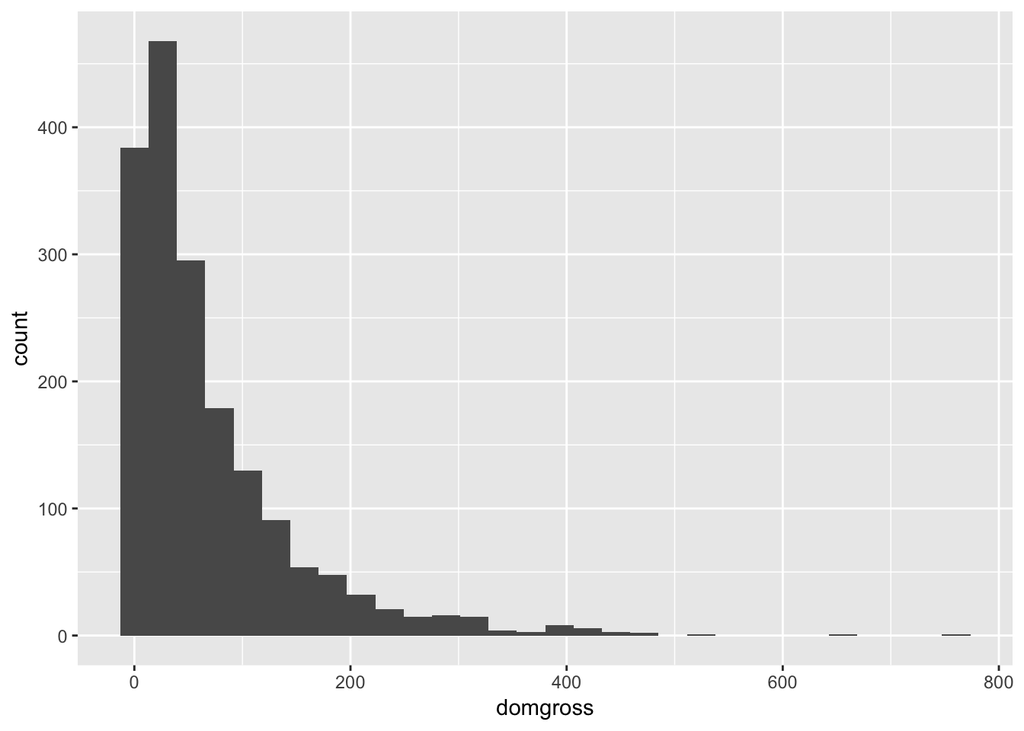

```r
# Histogram of domestic gross revenue
ggplot(data = bech_data, aes(x = domgross)) +
  geom_histogram()
```

Congratulations! You have made your first ggplot! Now let’s go over how to add some basic additions to our plots that will make them so much better.

#### Interpreting as Probability

Currenly the y-axis is listed as a count. Let’s change that so we can interpret the y-axis as a probability.

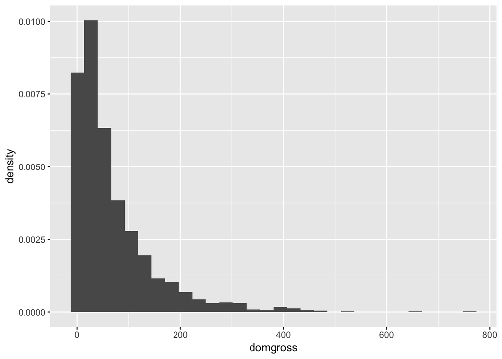

```r
# Histogram of domestic gross revenue as probability
ggplot(data = bech_data, aes(x = domgross, y = ..density..)) +
  geom_histogram()
```

#### Add a Title and axis labels

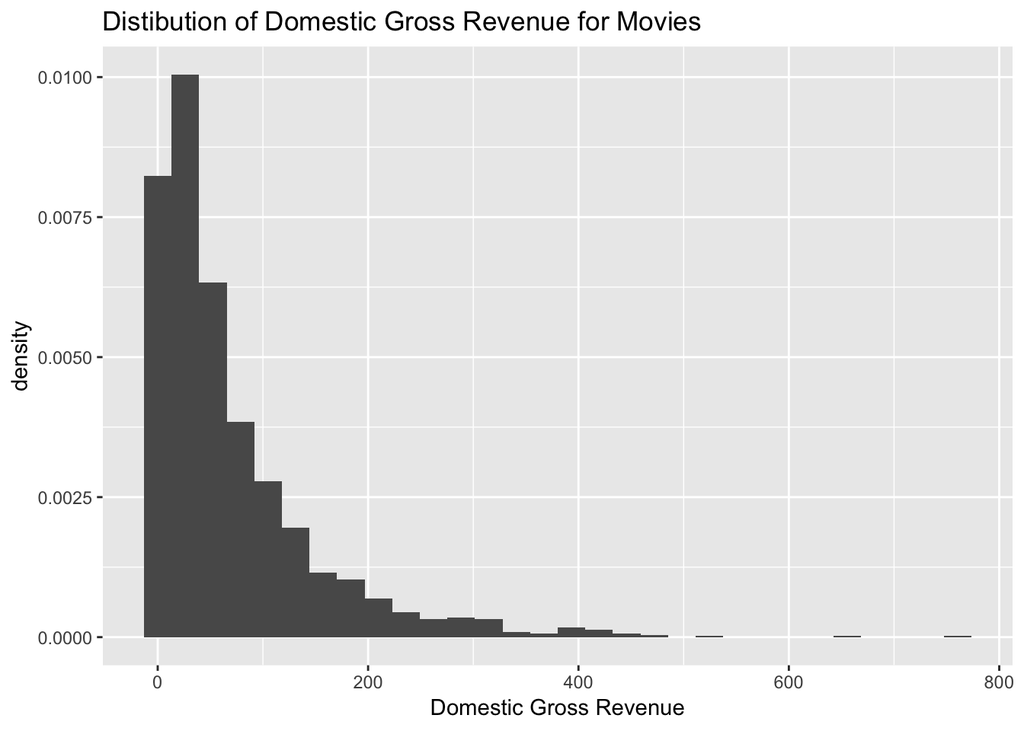

```r
# Histogram of domestic gross revenue as probability with title and labels
ggplot(data = bech_data, aes(x = domgross, y = ..density..)) +
  geom_histogram() +
  ggtitle("Distibution of Domestic Gross Revenue for Movies") +
  xlab("Domestic Gross Revenue")
```